# Question

Random variable $R$ is normally distributed with mean $\mu = 170$ and standard deviation $\sigma = 50$.
$$R \sim \text{N}(170,\,50)$$
Evaluate $P\left(\big|R-170\big| > 60\right)$. In other words, what is the probability that $R$ is outside $\pm60$ units from the mean?

# Solution

0.2302

# Use online app

[video (using app)](https://vimeo.com/531933725)

## Use a z table

[video (using z-table)](https://vimeo.com/531933369)

First, draw a sketch. We can label the $R$ axis by adding integer multiples of 50 to 170. We know to shade the two tails because values far from 170 satisfy the condition $\big|R-170\big| > 60$. We draw the boundaries at $170-60=110$ and $170+60=230$ because those are the solutions to $\big|R-170\big| = 60$. We can also rephrase the probability.

$$P\left(\big|R-170\big| > 60\right)
~=~ P\big(R<110 \text{ OR } R>230\big)$$

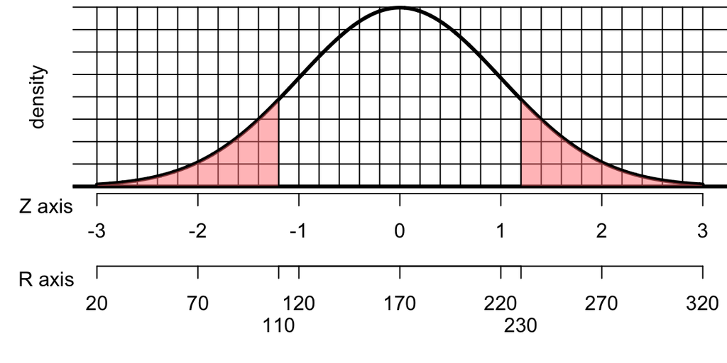

We calculate the $z$ values of the boundaries. Left boundary:
$$\begin{aligned}
z_1 &= \frac{110-170}{50} \\\\
&= \frac{-60}{50} \\\\
&= -1.2
\end{aligned}$$

Right boundary:

$$\begin{aligned}
z_2 &= \frac{230-170}{50} \\\\
&= \frac{60}{50} \\\\
&= 1.2
\end{aligned}$$

We have rephrased our problem into a **standard normal** probability problem, because

$$P\left(\big|R-170\big| > 60\right)
~=~ P\left(\big|Z\big|>1.2\right)$$

So, we just need to evaluate $P(|Z|>1.2)$. I will also point out that $\frac{60}{50} = 1.2$. In general, if $X$ is normally distributed, then:
$$P\left(\big|X-\mu\big|>d\right) ~=~
P\left(\big|Z\big| > \frac{d}{\sigma}\right)$$

From here we have a formula that lets us use the $z$ table. (We practiced this part before.)
$$\begin{aligned}
P(|Z|>1.2) &= 2- 2 \times P(Z<1.2) \\
&= 2 - 2 \times 0.8849 \\
&= 0.2302
\end{aligned}$$

# Meta-information

extype: num exsolution: 0.2302 exname: Get twotailarea from normal extol: 0.0002